# 705604096_stats101b_hw1

Jade Gregory

2023-08-16

## Question 1

```r
island_data <- read.csv("101b_Island_HW1.csv", header = TRUE)
island_data
```

```
##                  name age gender pulse.before.in.bpm pulse.after.in.bpm
## 1        Kelda Larsen  42 female                  69                124
## 2      Amber Watanabe  15 female                  91                146
## 3        Auna Collins  44   male                  87                145
## 4         Andrew Sato  93   male                  71                124
## 5        Carina Ghosh  83 female                  67                124
## 6       Magritte Sato  40 female                  77                133
## 7         Pia Bahadur  21 female                  83                137
## 8      Kazuki Summers  90   male                  70                127
## 9  Christian Blomgren  23   male                  66                120
## 10      Jonas Clausen  67   male                  73                129
## 11      Signe Solberg  39 female                  65                120
## 12     Natsume Masuda  20 female                  73                127
## 13     Harold Solberg  42   male                  67                123
## 14   William Blomgren  66   male                  65                120
```

[output cut: 27 more lines]

### Part 1

```r
t.test(island_data$pulse.after.in.bpm, island_data$pulse.before.in.bpm, paired = TRUE)
```

```
##
##  Paired t-test
##
## data:  island_data$pulse.after.in.bpm and island_data$pulse.before.in.bpm
## t = 166.13, df = 19, p-value < 2.2e-16
## alternative hypothesis: true mean difference is not equal to 0
## 95 percent confidence interval:
##  54.40582 55.79418
## sample estimates:
## mean difference
##            55.1
```

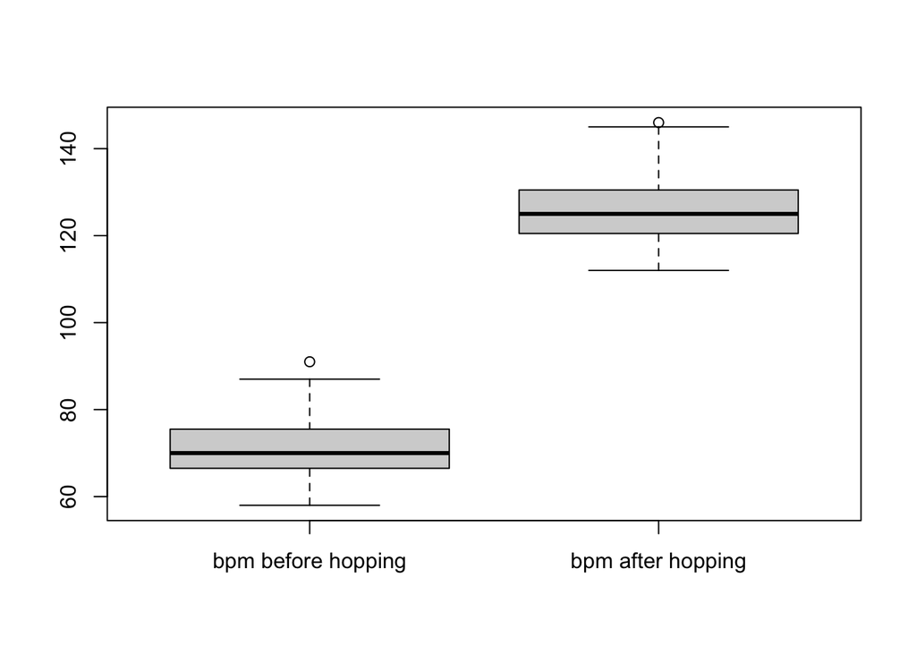

```r
boxplot(island_data$pulse.before.in.bpm, island_data$pulse.after.in.bpm, xaxt = "n")
axis(1, at = 1:2, labels = c("bpm before hopping","bpm after hopping"))
```

Our null hypothesis is that the true mean difference is equal to zero while our alternative hypothesis states that the true mean difference does not equal zero. From our paired t test, we see that our p-value is less than 2.2e-16 which is less than our significance level of 0.05 and we therefore reject our null hypothesis. From this we can conclude that the true mean difference does not equal zero. From our boxplot, we can clearly see how the two means are not equal, and therefore the true mean difference is not zero. This means that the average bpm of an individual before hopping is not equal to the average bpm of an individual after hopping. We can see that the hopping did in fact raise the Islander’s pulse Our sources of variation come from the differences amongst the surveyed individuals, including age and gender. To hold variables constant one can limit the area they choose Islanders from, or limit the age range that they choose from.

### Part 2

```r
t.test(island_data$pulse.before.in.bpm ~ island_data$gender)
```

```
##
##  Welch Two Sample t-test
##
## data:  island_data$pulse.before.in.bpm by island_data$gender
## t = 0.10495, df = 15.906, p-value = 0.9177
## alternative hypothesis: true difference in means between group female and group male is not equal to 0
## 95 percent confidence interval:
##  -7.683671  8.483671
## sample estimates:
## mean in group female   mean in group male
##                 71.9                 71.5
```

```r
t.test(island_data$pulse.after.in.bpm ~ island_data$gender)
```

```
##
##  Welch Two Sample t-test
##
## data:  island_data$pulse.after.in.bpm by island_data$gender
## t = 0.051355, df = 16.944, p-value = 0.9596
## alternative hypothesis: true difference in means between group female and group male is not equal to 0
## 95 percent confidence interval:
##  -8.018628  8.418628
## sample estimates:
## mean in group female   mean in group male
##                126.9                126.7
```

### Part 3

We could have taken their pulse during the hopping exercise to see how quickly it was increasing, and then we could have taken it five minutes after they stopped to see if the pulse returned to their original pulse before the hopping. We could have also recorded the experiment on the same individuals over a longer period of time, say over the course of a few months, to see if we would get consistent results. I would also limit the age range and area for which I chose Islanders in order to get more statistically significant results of a group of Islanders. I would analyze this data by determining the average pulse before hopping and then after hopping, to see if the pulse differed. The experimental design would be similar to the one that occurred in part (1).

## Question 2

```r
m_diff <- 11.5
df <- 24
t_stat <- -1.88
p_val <- 0.0723
```

```r
SE <- abs(m_diff / t_stat)
SE
```

```
## [1] 6.117021
```

Our standard error is 6.117021.

2. From a t table, we can determine that it is a two sided test since we can see that a p-value of 0.0723 correlates to a t-statistic of -1.88.
3. Since our p-value of 0.0723 is greater than our confidence level of 0.05 we fail to reject the null hypothesis and can conclude that there is no difference in the means.

```r
confint_num <- 2.064
ci_lower <- -1 * m_diff - confint_num * SE
ci_upper <- -1 * m_diff + confint_num * SE
confint <- c(ci_lower, ci_upper)
confint
```

```
## [1] -24.125532   1.125532
```

Our 95% confidence interval is (-24.125532, 1.125532).

## Question 3

1. The null hypothesis to be tested in this experiment is that there is no difference in the two means. The alternative hypothesis states that there is a difference in the two means.

$$H_0: \mu_1 = \mu_2 \\ H_1: \mu_1 \neq
\mu_2$$
b)

```r
machine1 <- c(16.03, 16.04, 16.05, 16.05, 16.02, 16.01, 15.96, 15.98, 16.02, 15.99)
machine2 <- c(16.02, 15.97, 15.96, 16.01, 15.99, 16.03, 16.04, 16.02, 16.01, 16.00)
mean1 <- mean(machine1)
mean2 <- mean(machine2)
sd1 <- 0.015
sd2 <- 0.018
n <- 10

z <- ( mean1 - mean2 ) / ( sqrt( (sd1^2 / n) + (sd2^2 / n) ) )
z
```

```
## [1] 1.349627
```

Since our z value is 1.349627 which is less than 1.96 and greater than -1.96, we fail to reject the null hypothesis and can conclude that there is no difference in the two means.

3. From a two tailed z table, our p-value is 0.17702 for a rounded z value of 1.35.

```r
confint_d_lower <- ( mean1 - mean2 ) - 1.96 * sqrt( (sd1^2 / n) + (sd2^2 / n) )
confint_d_upper <- ( mean1 - mean2 ) + 1.96 * sqrt( (sd1^2 / n) + (sd2^2 / n) )
confint_d <- c(confint_d_lower, confint_d_upper)
confint_d
```

```
## [1] -0.004522529  0.024522529
```

Our 95% confidence interval is (-0.004522529, 0.024522529).

## Question 4

```r
mydata <- data.frame("x10" = c(1530, 1530, 1440),
                 "x15" = c(1610, 1650, 1500),
                 "x20" = c(1560, 1730, 1530),
                 "x25" = c(1500, 1490, 1510)
                 )
df_aov <- aov(values ~ ind, data = stack(mydata))
summary(df_aov)
```

```
##             Df Sum Sq Mean Sq F value Pr(>F)
## ind          3  28633    9544   1.865  0.214
## Residuals    8  40933    5117
```

Since our p-value is 0.214 which is greater than our significance level of 0.05, we fail to reject the null hypothesis and can conclude that there is no difference in compressive strength due to rodding level.

2. From part (a), an F statistic of 1.865 has a p-value of 0.214.

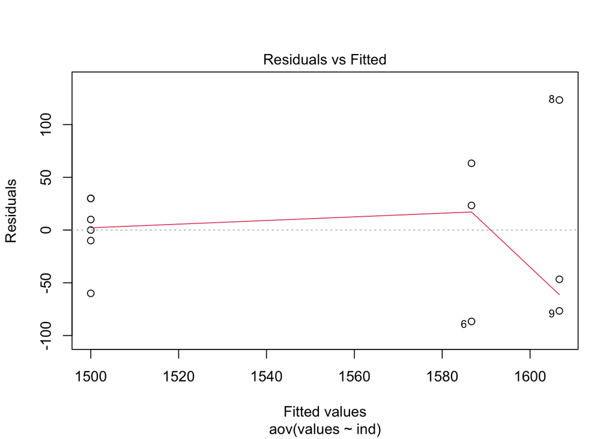

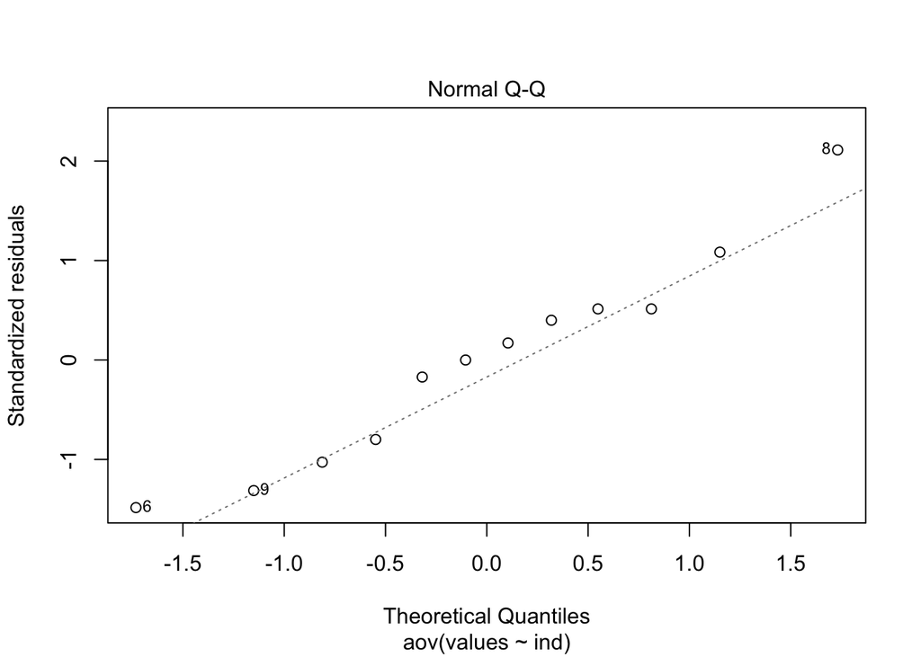

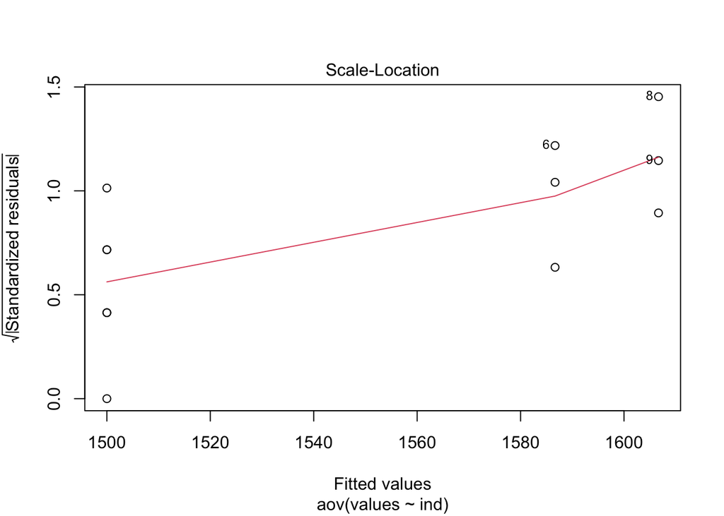

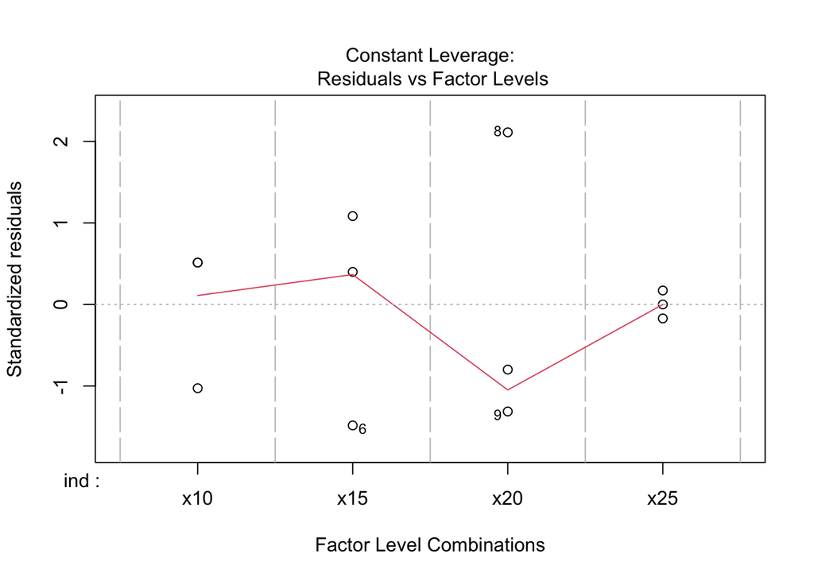

```r
plot(df_aov)
```

[figure not shown]

```r
curve(dt(x, df = 3), from = -4, to = 4, type = "l", ylab = " ", yaxt = "n", xaxt = "n", xlab= "Mean Compressive Strength", main = "Scaled t Distribution")
axis(1, at = -3:3, labels = c(1418, 1459, 1500, 1541, 1582, 1623, 1664))
points(x = c(-1, 1.1, 1.6), y = c(0,0, 0))
points(x = c(-1, 1.1, 1.6), y = c(0.025, 0.025 ,0.025), col = "white")
text(c(-1, 1.1, 1.6), c(0.025, 0.025 ,0.025), c("(10, 25)", "(15)", "(25)"))
```

[output not shown]